# Predicting Income Levels From Census Data Using Machine Learning

Michael D'Angelo (dangelo4) & Raghav Goyal (raghavg4)

### Project Definition

This project will be used to explore income levels in the United States. The primary question driving our research is: What are the key factors influencing an individual's income level in the United States? We aim to investigate the relationship between demographic and employment-based characteristics such as education, occupation, age, and others, and their impact on whether an individual's income exceeds $50,000 per year.

### Importance of the Research Question

Understanding the determinants of income levels is crucial for several reasons. Firstly, income disparity is a significant socio-economic issue that affects individuals and communities across the United States. By identifying the factors that contribute to this disparity, we can inform policy-making efforts aimed at reducing inequality and promoting economic mobility. Furthermore, gaining insights into the key drivers of income can help guide individuals in making informed decisions about education, career choices, and financial planning. Additionally, businesses and organizations can utilize this knowledge to develop targeted strategies for talent acquisition, employee retention, and diversity and inclusion initiatives.

Although the data we are exploring is from a 1994 census, it will still provide us with key insights into the determinants of income.

### Why Use Machine Learning?

Machine learning offers a powerful toolkit for analyzing complex datasets and uncovering patterns and relationships that may not be readily apparent through traditional statistical methods. By applying machine learning techniques to the "Adult Census Income" dataset, we can leverage its predictive capabilities to identify which variables have the most significant impact on an individual's income level.

Moreover, machine learning models provide a framework for building predictive models that can generalize well to unseen data, allowing us to make informed predictions about income levels for individuals beyond those included in the dataset. This predictive capability is essential for understanding the broader implications of the factors influencing income disparity and for designing targeted interventions to address them. Overall, machine learning serves as a valuable tool for exploring the complexities of income inequality and informing evidence-based policy and decision-making.

### Review of Literature

Income levels in the United States are shaped by a multitude of factors. Household characteristics, including income level, household size, number of workers, and housing, have been pinpointed as significant contributors to individual income inequality (Ma, 2023). Moreover, factors such as trust, civic norms, educational attainment, and ethnic homogeneity also influence income distribution (Knack & Keefer, 1997). Research indicates that age, gender, and homeownership status further impact income mobility. Furthermore, income inequality, ethnic diversity, and social capital within the United States are vital determinants of economic growth.

### Computing

Let us now move on to our own analysis and see what insights about this subject we can uncover with our data-driven approach.

We will be utilizing the programming language Python and its libraries to complete our analysis. The main libraries we will be using are Pandas for data manipulation and analysis, Numpy for scientific and mathematical computing, Matplotlib and Seaborn for data visualization and Sci-kit Learn for machine learning applications. We will also use XGBoost which is an additional software for creating gradient boosted tree based models.

```python
# Installing relvant libraries
!pip install -q ucimlrepo
!pip install -q xgboost
```

```python
# Importing modules
import pandas as pd
import numpy as np
import matplotlib.pylab as plt
%matplotlib inline
import seaborn as sns
sns.set_style("whitegrid")

from ucimlrepo import fetch_ucirepo
import warnings
warnings.filterwarnings('ignore')
from sklearn.model_selection import train_test_split, GridSearchCV
from sklearn.metrics import accuracy_score
from sklearn.ensemble import RandomForestClassifier
from sklearn.neighbors import KNeighborsClassifier
from sklearn.linear_model import LogisticRegression
from xgboost import XGBClassifier
from sklearn.metrics import classification_report, confusion_matrix, ConfusionMatrixDisplay
```

### Exploratory Data Analysis

```python
# fetch dataset
adult = fetch_ucirepo(id=2)

# data (as pandas dataframes)
X = adult.data.features
y = adult.data.targets
```

We are retreiving our dataset directly from the UC Irvine Machine Learning Repository. Although CSV versions of their various datasets can be found on their website and Kaggle, they have also created a Python package to source data directly which we have used above.

```python
df = pd.concat([y, X], axis=1)
df.head()
```

|  | income | age | workclass | fnlwgt | education | education-num | marital-status | occupation | relationship | race | sex | capital-gain | capital-loss | hours-per-week | native-country |
| --- | --- | --- | --- | --- | --- | --- | --- | --- | --- | --- | --- | --- | --- | --- | --- |
| 0 | <=50K | 39 | State-gov | 77516 | Bachelors | 13 | Never-married | Adm-clerical | Not-in-family | White | Male | 2174 | 0 | 40 | United-States |
| 1 | <=50K | 50 | Self-emp-not-inc | 83311 | Bachelors | 13 | Married-civ-spouse | Exec-managerial | Husband | White | Male | 0 | 0 | 13 | United-States |
| 2 | <=50K | 38 | Private | 215646 | HS-grad | 9 | Divorced | Handlers-cleaners | Not-in-family | White | Male | 0 | 0 | 40 | United-States |
| 3 | <=50K | 53 | Private | 234721 | 11th | 7 | Married-civ-spouse | Handlers-cleaners | Husband | Black | Male | 0 | 0 | 40 | United-States |
| 4 | <=50K | 28 | Private | 338409 | Bachelors | 13 | Married-civ-spouse | Prof-specialty | Wife | Black | Female | 0 | 0 | 40 | Cuba |

Here we can get a quick look at how our data looks. The variable we want to predict is income which comes as a binary class . The positive clas is greater than 50,000 USD and the negative class is less than or equal to 50,000 USD.

```python
# Remove periods from the 'income' column
df['income'] = df['income'].str.replace(r'\.', '', regex=True)

df['income'].value_counts()
```

```
income
<=50K    37155
>50K     11687
Name: count, dtype: int64
```

Since the values in the *income* column came in a few different formats, we are standardizing how they look for ease of interpretation. Here we can see that the negative class has more than three times the number of samples that that of the positive class. This is a thing to consider during our modeling.

```python
df.describe().T
```

|  | count | mean | std | min | 25% | 50% | 75% | max |
| --- | --- | --- | --- | --- | --- | --- | --- | --- |
| age | 48842.0 | 38.643585 | 13.710510 | 17.0 | 28.0 | 37.0 | 48.0 | 90.0 |
| fnlwgt | 48842.0 | 189664.134597 | 105604.025423 | 12285.0 | 117550.5 | 178144.5 | 237642.0 | 1490400.0 |
| education-num | 48842.0 | 10.078089 | 2.570973 | 1.0 | 9.0 | 10.0 | 12.0 | 16.0 |
| capital-gain | 48842.0 | 1079.067626 | 7452.019058 | 0.0 | 0.0 | 0.0 | 0.0 | 99999.0 |
| capital-loss | 48842.0 | 87.502314 | 403.004552 | 0.0 | 0.0 | 0.0 | 0.0 | 4356.0 |
| hours-per-week | 48842.0 | 40.422382 | 12.391444 | 1.0 | 40.0 | 40.0 | 45.0 | 99.0 |

The people in this datset range from 17 to 90 years old, with an average age of around 39. It seems most people work the standard 40 hour week, although there is someone working almost 100 hours a week!

```python
df.info()
```

```
<class 'pandas.core.frame.DataFrame'>
RangeIndex: 48842 entries, 0 to 48841
Data columns (total 15 columns):
 #   Column          Non-Null Count  Dtype
---  ------          --------------  -----
 0   income          48842 non-null  object
 1   age             48842 non-null  int64
 2   workclass       47879 non-null  object
 3   fnlwgt          48842 non-null  int64
 4   education       48842 non-null  object
 5   education-num   48842 non-null  int64
 6   marital-status  48842 non-null  object
 7   occupation      47876 non-null  object
 8   relationship    48842 non-null  object
 9   race            48842 non-null  object
 10  sex             48842 non-null  object
 11  capital-gain    48842 non-null  int64
 12  capital-loss    48842 non-null  int64
 13  hours-per-week  48842 non-null  int64
 14  native-country  48568 non-null  object
dtypes: int64(6), object(9)
memory usage: 5.6+ MB
```

We can see we have 14 distinct features besides our target variable and a mix of numerical and categorical data types. This is something we will need to tend to when it comes to modeling.

It is also clear that columns like *workclass*, *occupation*, and *native-country* have some missing values. Since these are not a substantial number, we will simply drop these rows instead of filling these or using resampling methods.

```python
# Dropping Null Values
df = df.dropna()
```

Let's move on to some visualizations in order to get a better understanding of the data.

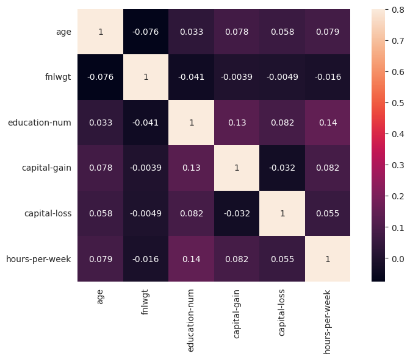

```python
# Excluding Categorical Columns
columns_to_exclude = ['income', 'workclass', 'education', 'marital-status', 'occupation', 'relationship', 'race', 'sex', 'native-country']

# Correlation Heatmap
df_selected = df.drop(columns=columns_to_exclude)
corrmat = df_selected.corr()
plt.figure(figsize=(8, 6))
sns.heatmap(corrmat, vmax=.8, square=True, annot=True)
plt.tight_layout()
```

Here we have a correlation plot of all the numerical features. It seems like none of the features are that correlated with each other, with the maximum coefficient being 0.14. This is useful for our modeling purposes.

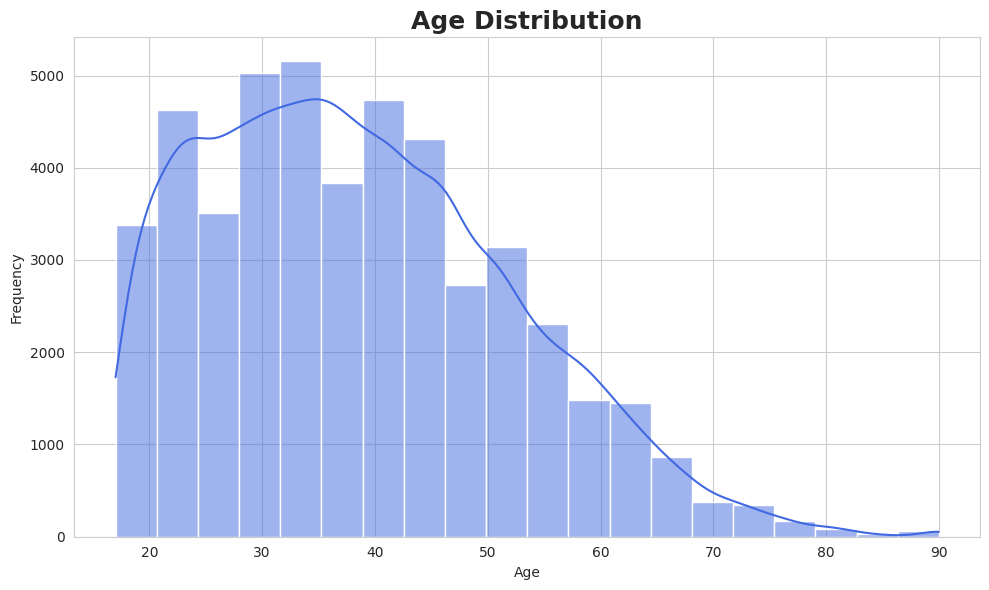

```python
# Distribution of Age
plt.figure(figsize=(10, 6))
plt.title('Age Distribution', fontsize=18, fontweight='bold')
sns.histplot(df['age'], kde=True, color='royalblue', bins=20)
plt.xlabel('Age')
plt.ylabel('Frequency')
plt.tight_layout()
```

We can see that the distribution of *Age* has a right-skew, with the majority of people being 20-50 years old. This makes sense as this range encapsulates the age of most people who are employed.

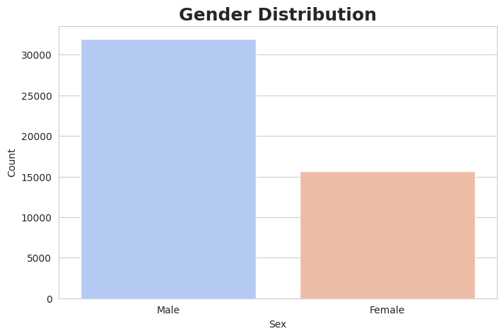

```python
# Count of Gender
plt.figure(figsize=(8, 5))  # Set the figure size
plt.title('Gender Distribution', fontsize=18, fontweight='bold')
sns.countplot(x='sex', data=df, palette='coolwarm')
plt.xlabel('Sex')
plt.ylabel('Count')
plt.tight_layout()
```

There are around double the number of males in the dataset compared to females. This may prove an interesting factor when it comes to prediction. Let's now check their comparison with income levels.

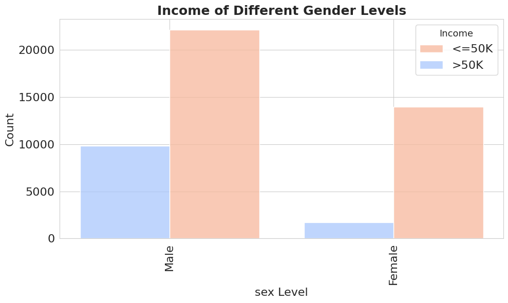

```python
# Gender vs Income
plt.figure(figsize=(10, 6))
sns.histplot(data=df, x='sex', hue='income', multiple='dodge', shrink=0.8,
             palette='coolwarm', hue_order=['>50K', '<=50K'], discrete=True)
plt.title('Income of Different Gender Levels', fontsize=18, fontweight='bold')
plt.xticks(rotation=90, fontsize=16)
plt.yticks(fontsize=16)
plt.xlabel('sex Level', fontsize=16)
plt.ylabel('Count', fontsize=16)
plt.legend(title='Income', labels=['<=50K', '>50K'], fontsize=16, title_fontsize='13')
plt.tight_layout()
```

Across both genders, there are more instances being below 50k. However, the discrepancy is larger for females.

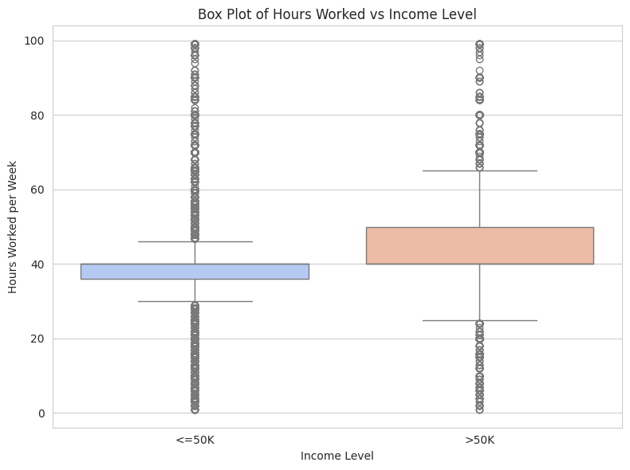

```python
# Hours per Week Vs Income
plt.figure(figsize=(8, 6))
sns.boxplot(x='income', y='hours-per-week', data=df, palette = "coolwarm")
plt.title('Box Plot of Hours Worked vs Income Level')
plt.xlabel('Income Level')
plt.ylabel('Hours Worked per Week')
plt.tight_layout()
```

It seems individuals in the higher income class tend to work longer hours on average. This makes sense as people are typically paid accordingly to how long they work. Although, this could indicate that higher paying jobs may require more work.

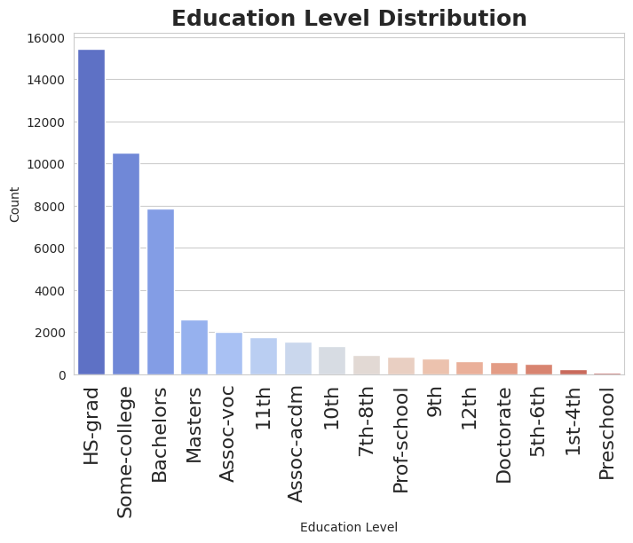

```python
# Count of Education Levels
education_counts = df['education'].value_counts().sort_values(ascending=False)

plt.figure(figsize=(8, 5))  # Set the figure size
plt.title('Education Level Distribution', fontsize=18, fontweight='bold')
sns.countplot(x='education', data=df, order=education_counts.index, palette='coolwarm')
plt.xlabel('Education Level')
plt.ylabel('Count')
plt.xticks(fontsize=16,rotation = 90)
plt.show()
```

Most people in the sample have completed a high school education, with around half that number having up till a bachelor's degree. Interestingly enough, there are a few people with no education past pre-school.

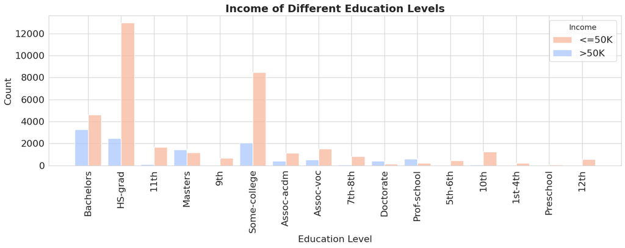

```python
# Education Levels vs Income
plt.figure(figsize=(15, 6))
sns.histplot(data=df, x='education', hue='income', multiple='dodge', shrink=0.8,
             palette='coolwarm', hue_order=['>50K', '<=50K'], discrete=True)
plt.title('Income of Different Education Levels', fontsize=18, fontweight='bold')
plt.xticks(rotation=90, fontsize=16)
plt.yticks(fontsize=16)
plt.xlabel('Education Level', fontsize=16)
plt.ylabel('Count', fontsize=16)
plt.legend(title='Income', labels=['<=50K', '>50K'], fontsize=16, title_fontsize='13')
plt.tight_layout()
```

There seems to be some pattern where the ratio of above 50k to below 50k increases with higher education levels.

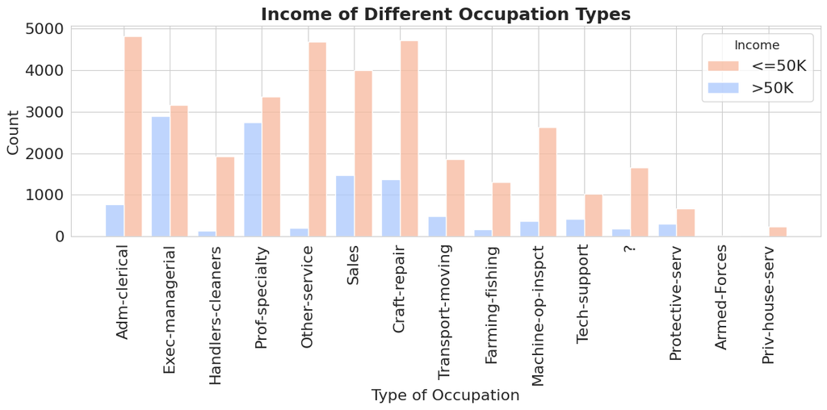

```python
# Occupation vs Income
plt.figure(figsize=(12, 6))
sns.histplot(data=df, x='occupation', hue='income', multiple='dodge', shrink=0.8,
             palette='coolwarm', hue_order=['>50K', '<=50K'], discrete=True)
plt.title('Income of Different Occupation Types', fontsize=18, fontweight='bold')
plt.xticks(rotation=90, fontsize=16)
plt.yticks(fontsize=16)
plt.xlabel('Type of Occupation', fontsize=16)
plt.ylabel('Count', fontsize=16)
plt.legend(title='Income', labels=['<=50K', '>50K'], fontsize=16, title_fontsize='13')
plt.tight_layout()
```

Managerial Excutives and people in specialty professions are almost equally likley to have an income above 50k than below. All other occupation types have a far greater probability to have an income below 50k.

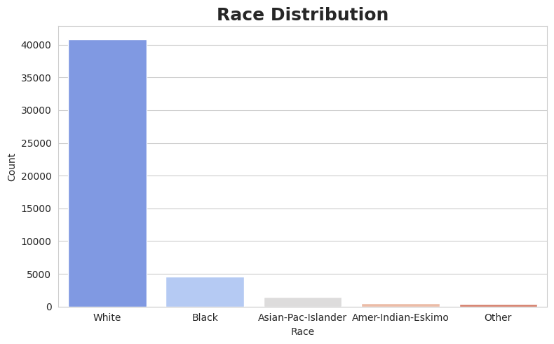

```python
# Counts of Race Type
plt.figure(figsize=(8, 5))
plt.title('Race Distribution', fontsize=18, fontweight='bold')
sns.countplot(x='race', data=df, palette='coolwarm')
plt.xlabel('Race')
plt.ylabel('Count')
plt.tight_layout()
```

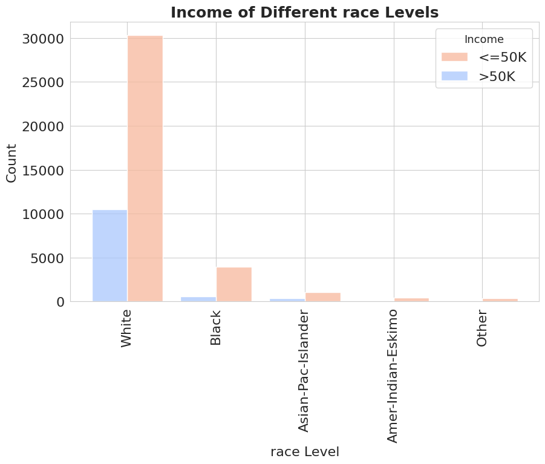

```python
# Race vs Income Plot
plt.figure(figsize=(10, 6))
sns.histplot(data=df, x='race', hue='income', multiple='dodge', shrink=0.8,
             palette='coolwarm', hue_order=['>50K', '<=50K'], discrete=True)

plt.title('Income of Different race Levels', fontsize=18, fontweight='bold')
plt.xticks(rotation=90, fontsize=16)
plt.yticks(fontsize=16)
plt.xlabel('race Level', fontsize=16)
plt.ylabel('Count', fontsize=16)
plt.legend(title='Income', labels=['<=50K', '>50K'], fontsize=16, title_fontsize='13')
plt.show()
```

Most people in the dataset are ethnically white. This means we will not have much insight as to how income differs between these racial groups.

Let us now move into the modeling and machine learning aspect of our research.

### Modeling

```python
# Converting Categorical Data into Numerical with Dummy Variables
final_df= pd.get_dummies(df,drop_first=True)
```

```python
final_df.head()
```

|  | age | fnlwgt | education-num | capital-gain | capital-loss | hours-per-week | income_>50K | workclass_Federal-gov | workclass_Local-gov | workclass_Never-worked | ... | native-country_Portugal | native-country_Puerto-Rico | native-country_Scotland | native-country_South | native-country_Taiwan | native-country_Thailand | native-country_Trinadad&Tobago | native-country_United-States | native-country_Vietnam | native-country_Yugoslavia |
| --- | --- | --- | --- | --- | --- | --- | --- | --- | --- | --- | --- | --- | --- | --- | --- | --- | --- | --- | --- | --- | --- |
| 0 | 39 | 77516 | 13 | 2174 | 0 | 40 | False | False | False | False | ... | False | False | False | False | False | False | False | True | False | False |
| 1 | 50 | 83311 | 13 | 0 | 0 | 13 | False | False | False | False | ... | False | False | False | False | False | False | False | True | False | False |
| 2 | 38 | 215646 | 9 | 0 | 0 | 40 | False | False | False | False | ... | False | False | False | False | False | False | False | True | False | False |
| 3 | 53 | 234721 | 7 | 0 | 0 | 40 | False | False | False | False | ... | False | False | False | False | False | False | False | True | False | False |
| 4 | 28 | 338409 | 13 | 0 | 0 | 40 | False | False | False | False | ... | False | False | False | False | False | False | False | False | False | False |

5 rows × 101 columns

Since we have created dummies for the categorical columns, there are now technically 100 predictive features, although these additional columns are purely based off their parent variables.

```python
# Setting Target Variables and Features
y = final_df['income_>50K']
X = final_df.drop( columns = ['income_>50K'])
```

```python
# Splitting Training and Test Data
X_train, X_test, y_train, y_test = train_test_split(X, y, test_size = 0.2, random_state = 0)
```

We have decided use 80% of our data to train the models, and the remaning 20% to test it. Since we are working with over 45,000 samples, there is plenty of data for both our training and test sets and research has shown using 70-80% of data for training produces optimal results.

```python
# Scaling Columns to Standardize
from sklearn.preprocessing import StandardScaler

scaler = StandardScaler()

X_train = pd.DataFrame(scaler.fit_transform(X_train), columns = X.columns)
X_test = pd.DataFrame(scaler.transform(X_test), columns = X.columns)
```

The features have been normalized in order to create a consistent scale. This will especially help with less flexible models that may be inequipped to handle a large range of values.

```python
# Initializing models and Creating Dictionary for Results
models = {"Logistic Regression": LogisticRegression(), "K-Nearest Neighbors": KNeighborsClassifier(),
"Random Forest": RandomForestClassifier(), "XGBoost": XGBClassifier()}

# Creating a function to fit and score the models
def fit_score(models, X_train, X_test, y_train, y_test):
    # Random seed for consistent results
    np.random.seed(0)
    # Empty dictionary to keep model scores
    model_scores ={}
    # Loop for models
    for name, model in models.items():
        # Fitting model
        model.fit(X_train, y_train)
        # Evaluate model and append score to model_scores
        model_scores[name] = 1 - model.score(X_test, y_test)
    return model_scores
```

Four distinct models- Logistic Regression, K-Nearest Neighbors, Random Forest, and XGBoost will be used for the binary classification task. Initally, the models's default parameters will be used to estimate their accurary and test error. For KNN, the default number of neighbors is 5.

```python
# Test Error Rates of 4 Models
model_scores = fit_score(models=models,
X_train=X_train, X_test=X_test, y_train=y_train, y_test=y_test)
model_scores
```

```
{'Logistic Regression': 0.1459317585301837,
 'K-Nearest Neighbors': 0.17963254593175848,
 'Random Forest': 0.14383202099737535,
 'XGBoost': 0.1281889763779528}
```

We can see that each of the four models perform fairly respectably with all of them achieving a test error rate of below 20%. It is clear to see that XGBoost deduces the lowest error, hence, we will select this model for further evaluation since we desire the greatest predictive capacity.

```python
# Hyperparamter Tuning
model = XGBClassifier(use_label_encoder=False)
np.random.seed(0)
parameters = {
    'min_child_weight': [1, 3],
    'colsample_bytree': [0.6, 0.8, 1.0],
    'subsample': [0.6, 0.8, 1.0],
    'learning_rate': [0.01, 0.1, 0.2]
}
grid_search = GridSearchCV(estimator=model, param_grid=parameters, scoring='accuracy', n_jobs=-1, cv=3, verbose=3)
grid_search.fit(X_train, y_train)
print("Best parameters:", grid_search.best_params_)
print("Best score:", grid_search.best_score_)
```

```
Fitting 3 folds for each of 54 candidates, totalling 162 fits
Best parameters: {'colsample_bytree': 0.6, 'learning_rate': 0.1, 'min_child_weight': 1, 'subsample': 1.0}
Best score: 0.873136264360673
```

With the XGBoost model, tuning will be conducted using a grid search of potential paramters. The model that achieves the greatest accuracy with its set of paramters will chosen as the best model. Along with the grid search, the above function will perform cross-validation with 3 folds such that we generate a more consistent idea of model performance.

```python
# Best Parameter Accuracy
best_model = grid_search.best_estimator_
predictions = best_model.predict(X_test)
accuracy = accuracy_score(y_test, predictions)
print("Test set accuracy: %.2f%%" % (accuracy * 100.0))
print("Test set erorr rate: %.2f%%" % ((1 - accuracy) * 100))
```

```
Test set accuracy: 87.39%
Test set erorr rate: 12.61%
```

After hyperparamter tuning, we achieve a marginally better model as test error rate was reduced by approximately 0.2%.

```python
print(classification_report(y_test, predictions))
```

```
              precision    recall  f1-score   support

       False       0.89      0.95      0.92      7226
        True       0.80      0.64      0.71      2299

    accuracy                           0.87      9525
   macro avg       0.84      0.79      0.81      9525
weighted avg       0.87      0.87      0.87      9525
```

Although model accuracy is very high, the algorithm is not able to generalize very optimally. It can be seen that the model is better at predicting the negative class rather than the positive class given the lower precision and substantially lower recall scores for the *True* class. Given the class imbalance, this is understandable and we can see that the macro and weighted averages still perform quite well. Let's grab a closer look with the confusion matrix for model predictions.

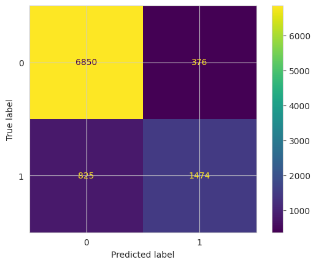

```python
# Test Set Confusion Matrix
cm = confusion_matrix(y_test, predictions, labels = best_model.classes_)
disp = ConfusionMatrixDisplay(cm, display_labels = best_model.classes_)
disp.plot()
plt.show()
```

We can confirm there are some misclassifications, especially with the model favoring to predict the negative class rather than the positive class. However, this is still very promising performance and something we can definitely extract insights from.

Finally, lets take a look at feature importance which will aid our inference.

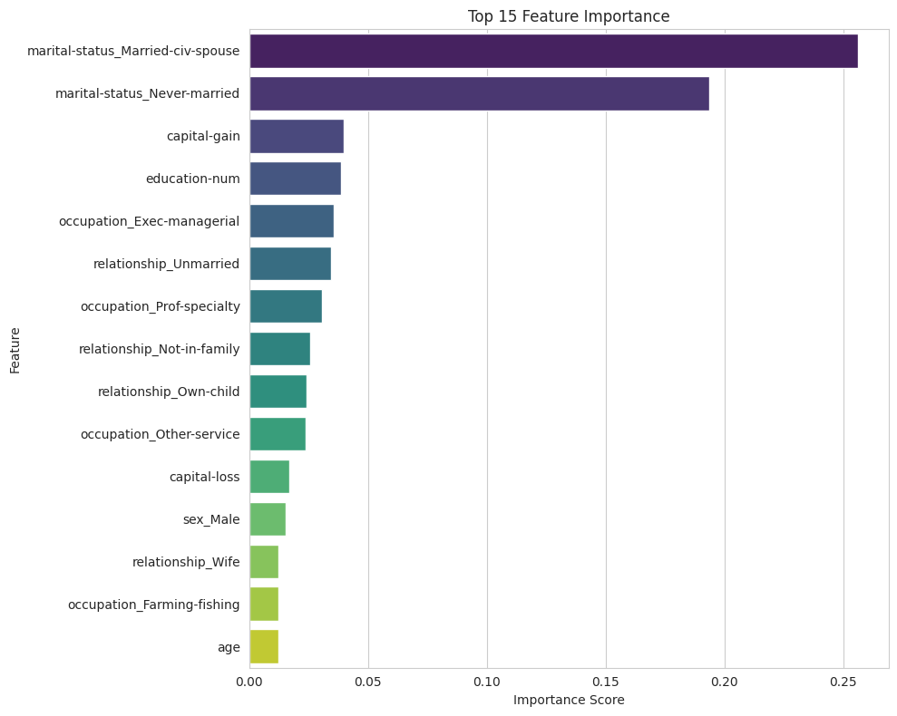

```python
# Feature Importance for XGBoost Classifier
feat_imp = best_model.feature_importances_
feat_names = X_train.columns
feat_imp_df = pd.DataFrame({"Feature": feat_names, "Importance": feat_imp})
feat_imp_df = feat_imp_df.sort_values(by = "Importance", ascending = False).head(15)

plt.figure(figsize = (10, 8))
sns.barplot(x = "Importance", y = "Feature", data = feat_imp_df, palette = "viridis")
plt.title('Top 15 Feature Importance')
plt.xlabel('Importance Score')
plt.ylabel('Feature')
plt.tight_layout()
```

Other key features happen to be capital gains and losses, level of education- which we found earlier is likley to be a key indicator, and two occupation types. These two occupations are the same ones we identified earlier that were far more likely to have >50k samples in them as compared to other jobs.

### Wrapping Up

Overall, this has been a very fruitful experience where we have had the opportunity to showcase our machine learning knowledge but we have uncovered plenty of knowledge along with it. These insights can be taken to subject-matter experts, policy-makers and more for better understanding on how adult census data can impact income levels.

### References

Becker, Barry and Kohavi, Ronny. (1996). Adult. UCI Machine Learning Repository. https://doi.org/10.24432/C5XW20

Ma, S. (2023). A study of inequality of opportunity in income distribution. Journal of Economics Trade and Marketing Management, 5(1), p64. https://doi.org/10.22158/jetmm.v5n1p64

Knack, S. and Keefer, P. (1997). Does social capital have an economic payoff? a cross-country investigation. The Quarterly Journal of Economics, 112(4), 1251-1288. https://doi.org/10.1162/003355300555475